# Analyse des survivants du Titanic

Antoine Legrand

12/11/2026

## Les données

Le jeu `TitanicSurvival` (package carData) décrit **1309 passagers** : survie, sexe, âge et classe du billet. L’âge est manquant pour 263 passagers, ces lignes sont ignorées dans les calculs sur l’âge.

## Survie globale

| Survie | Part (%) |
| --- | --- |
| no | 61.8 |
| yes | 38.2 |

Environ **38.2 %** des passagers ont survécu.

| Survie | Effectif | Âge moyen | Âge médian | Écart-type |
| --- | --- | --- | --- | --- |
| no | 809 | 30.5 | 28 | 13.9 |
| yes | 500 | 28.9 | 28 | 15.1 |

## Survie selon le sexe

Part de survivants par sexe (%)

|  | no | yes |
| --- | --- | --- |
| female | 27.3 | 72.7 |
| male | 80.9 | 19.1 |

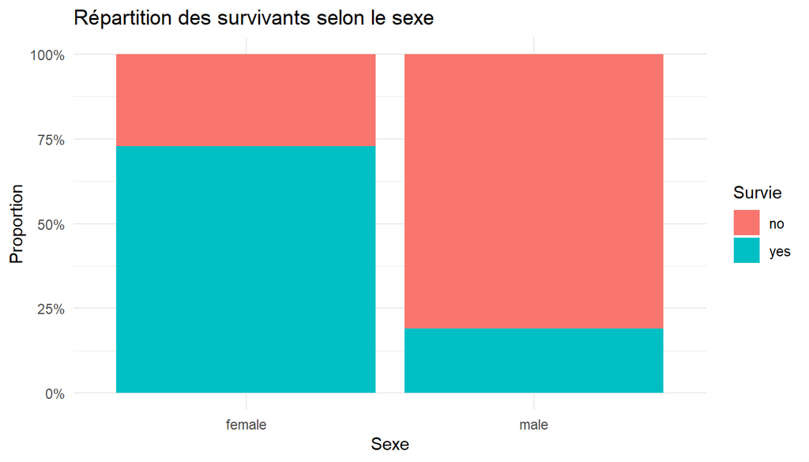

Le sexe est le facteur le plus marqué : **72.7 %** des femmes survivent contre **19.1 %** des hommes. La consigne « les femmes et les enfants d’abord » se retrouve dans les données.

## Survie selon la classe

Part de survivants par classe (%)

|  | no | yes |
| --- | --- | --- |
| 1st | 38.1 | 61.9 |
| 2nd | 57.0 | 43.0 |
| 3rd | 74.5 | 25.5 |

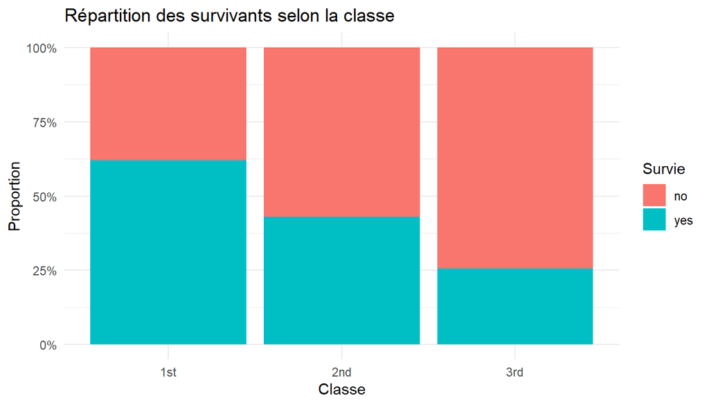

La survie diminue avec la classe : **61.9 %** en 1re, 43 % en 2e et **25.5 %** en 3e. Les passagers de 1re classe étaient plus proches des canots.

## Âge et survie

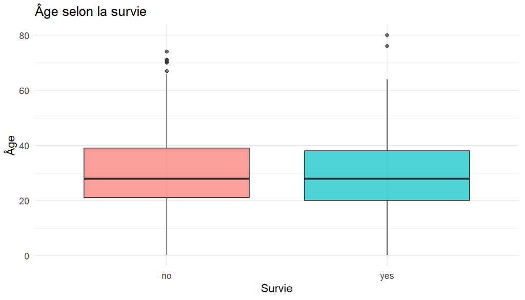

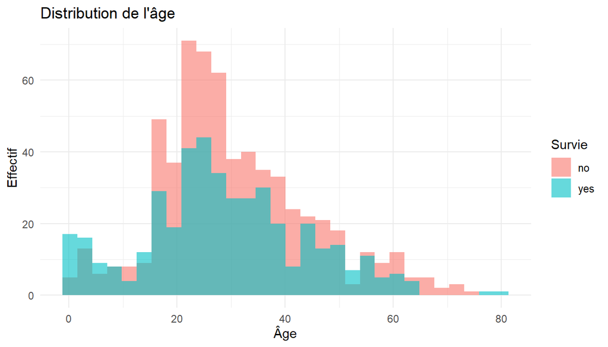

Les survivants sont un peu plus jeunes en moyenne, mais l’écart est faible. Les enfants ont eu de meilleures chances, ce que l’histogramme montre.

## Tests statistiques

| Test | Statistique | ddl | p-value |
| --- | --- | --- | --- |
| Khi-deux : sexe x survie | 363.6 | 1 | < 1e-16 |
| Khi-deux : classe x survie | 127.9 | 2 | < 1e-16 |

Les liens entre survie et sexe, puis entre survie et classe, sont **très significatifs** (p < 0,05). Le test t sur l’âge donne une p-value de 0.077. Il est à lire avec prudence à cause des valeurs manquantes.

## Limites

Ces résultats sont descriptifs. Le sexe, la classe et l’âge sont corrélés entre eux, donc on ne peut pas parler de causalité. Une régression logistique mesurerait l’effet de chaque variable toutes choses égales par ailleurs.